# `SpaDES` in action

Alex M Chubaty & Eliot McIntire

September 14, 2016

# 1 Examples

1. The [demo modules](https://github.com/PredictiveEcology/SpaDES/blob/master/inst/sampleModules/SpaDES_sampleModules/SpaDES_sampleModules.Rmd) in the `SpaDES` package
   - [caribouMovement](https://github.com/PredictiveEcology/SpaDES/blob/master/inst/sampleModules/caribouMovement/caribouMovement.R)
   - [fireSpread](https://github.com/PredictiveEcology/SpaDES/blob/master/inst/sampleModules/fireSpread/fireSpread.R)
   - [randomLandscapes](https://github.com/PredictiveEcology/SpaDES/blob/master/inst/sampleModules/randomLandscapes/randomLandscapes.R)
2. Simple forest dynamics model (with caribou) ([LCC2005](http://htmlpreview.github.io/?https://github.com/PredictiveEcology/SpaDES-modules/blob/master/modules/LCC2005/LCC2005.html))
3. SpaDES-Landis Biomass Succession
4. Wolf IBM ([wolfAlps](http://htmlpreview.github.io/?https://github.com/PredictiveEcology/SpaDES-modules/blob/master/modules/wolfAlps/wolfAlps.html))
5. A shiny app on shinyapps.io (*e.g.*, [Proof of concept](https://spades.shinyapps.io/ForestChange_ProofOfConcept/))

# 2 Demo modules in `SpaDES` package

- The [demo modules](https://github.com/PredictiveEcology/SpaDES/blob/development/inst/sampleModules/SpaDES_sampleModules/SpaDES_sampleModules.Rmd) are simple, proof of concept modules.
- There are 3 different types of modules:
  - Event (fireSpread)
  - Agent (caribouMovement)
  - Data generation (randomLandscapes)
- *How to find them:*

```r
# Locate SpaDES on your computer; they are in the sampleModule folder
whereSpaDES <- find.package(package  = "SpaDES")
whereSamples <- system.file('sampleModules', package = 'SpaDES')
file.path(whereSamples, 'caribouMovement', 'caribouMovement.R') %>%
  file.edit()
```

# 3 Simple forest dynamics model

- More modules than `SpaDES` demo
- Vegetation component is simple, but data-driven (LCC 2005)
- Neither caribou, nor fire are data-driven
- During simulation, it shows:
  - maps
  - data summary plots
  - text legends
  - colour matching between map and histogram
  - modular plotting (each module is unaware of other plots)

## 3.1 Simple forest dynamics model

- Freely available from the SpaDES-Modules repository
- This repository is intended to be like CRAN, but for `SpaDES` modules; makes them easy to distribute to others
- *How to find it:*

```r
# specify where to save files
moduleDir <- file.path(tempdir(), 'SpaDES_modules')

# download all necessary modules
downloadModule('LCC2005', path = moduleDir, data = TRUE)

# look at module or helper .Rmd file
openModules('LCC2005', path = moduleDir)
```

# 4 SpaDES-Landis Biomass Succession

- This is a rewrite in R of a core LANDIS vegetation dynamics module
- Slightly different implementation, making it faster under many situations
- Cross-platform (LANDIS is Windows-only)
- Allows scientist easier access to code, *e.g.*,
  - making growth climate sensitive
  - changing mortality functions
  - dividing up large problems into small parallel problems
- Not yet published

## 4.2 SpaDES-Landis Biomass Succession

## 4.3 Running the app

This is not publically available yet…

```r
shiny::runApp("~/GitHub/LandwebApp/")
```

# 5 Wolf IBM (wolfAlps)

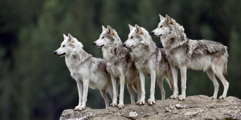

- Agent based model of demography and dispersal of wolves in the Italian Alps
- R port of the original SELES model that was used in (Marucco and McIntire 2010)
- Can run this on your computer, in R

## 5.1 Wolf IBM (wolfAlps)

- Features:
  - Incremental visuals
  - One module
  - Progress bar
  - Caching (automatic saving)
  - Parallel simulations
  - Summarizing across parallel runs
- [Go to model](http://htmlpreview.github.io/?https://github.com/PredictiveEcology/SpaDES-modules/blob/master/modules/wolfAlps/wolfAlps.html)

## 5.2 Wolf IBM (wolfAlps)

- Freely available from the SpaDES-Modules repository

```r
downloadModule("wolfAlps", path = moduleDir, data = TRUE)
```

- The `.Rmd` file shows how to run it:

```r
openModules("wolfAlps", path = moduleDir)
```

# 6 A shiny app on shinyapps.io

https://spades.shinyapps.io/ForestChange_ProofOfConcept/

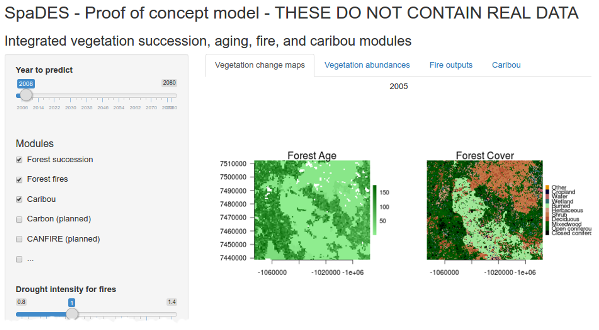

## 6.1 Features:

# 7 Ecological modelling in `SpaDES`

During this workshop we will learn how to:

- break down ecological processes into discrete events;
- organize ecological processes into `SpaDES` modules;
- rapidly prototype and develop complex ecological models in `SpaDES`;
- parameterize and evaluate simulation models;
- perform scenario analyses, *e.g.*, for decision support;
- build portable, reproducible models;
- share models, analyses, and code.

# 8 Where to get help

- package help docs (*e.g.*, [overview of `SpaDES` package](http://www.rdocumentation.org/packages/SpaDES/versions/1.2.0/topics/SpaDES-package)):

```r
?SpaDES
```

- package vignettes ([link](https://github.com/PredictiveEcology/SpaDES/wiki/Help-Vignettes))
- `SpaDES` wiki ([link](https://github.com/PredictiveEcology/SpaDES/wiki/))
- `SpaDES` user group ([link](https://groups.google.com/d/forum/spades-users))
- bug reports ([link](https://github.com/PredictiveEcology/SpaDES/issues/))

# 9 Next

Thinking the `SpaDES` way ([slides](http://Rpubs.com/PredictiveEcology/Archives-Sept16-02-thinking-the-spades-way))